# Titanic Data Clean

Ricardo Garcia Ruiz

10 de junio, 2018

# 1 Práctica 2: Limpieza y validación de los datos

## 1.1 Descripción de la Práctica a realizar

El objetivo de esta actividad será el tratamiento de un dataset, que puede ser el creado en la práctica 1 o bien cualquier dataset libre disponible en Kaggle (https://www.kaggle.com). Algunos ejemplos de dataset con los que podéis trabajar son: * Red Wine Quality (https://www.kaggle.com/uciml/red-wine-quality-cortez-et-al-2009) * Titanic: Machine Learning from Disaster (https://www.kaggle.com/c/titanic) * Predict Future Sales (https://www.kaggle.com/c/competitive-data-sciencepredict-future-sales/).

Los últimos dos ejemplos corresponden a competiciones activas de Kaggle de manera que, opcionalmente, podríais aprovechar el trabajo realizado durante la práctica para entrar en alguna de estas competiciones.

Siguiendo las principales etapas de un proyecto analítico, las diferentes tareas a realizar (y justificar) son las siguientes:

1. Descripción del dataset. ¿Por qué es importante y qué pregunta/problema pretende responder?
2. Integración y selección de los datos de interés a analizar.
3. Limpieza de los datos:  
   3.1. ¿Los datos contienen ceros o elementos vacíos? ¿Cómo gestionarías cada uno de estos casos? 3.2. Identificación y tratamiento de valores extremos.
4. Análisis de los datos.  
   4.1. Selección de los grupos de datos que se quieren analizar/comparar (planificación de los análisis a aplicar).  
   4.2. Comprobación de la normalidad y homogeneidad de la varianza.  
   4.3. Aplicación de pruebas estadísticas para comparar los grupos de datos. En función de los datos y el objetivo del estudio, aplicar pruebas de contraste de hipótesis, correlaciones, regresiones, etc.
5. Representación de los resultados a partir de tablas y gráficas.
6. Resolución del problema. A partir de los resultados obtenidos, ¿cuáles son las conclusiones? ¿Los resultados permiten responder al problema?
7. Código: Hay que adjuntar el código, preferiblemente en R, con el que se ha realizado la limpieza, análisis y representación de los datos. Si lo preferís, también podéis trabajar en Python.

## 1.2 Objetivos

Los objetivos concretos de esta práctica son:

- Aprender a aplicar los conocimientos adquiridos y su capacidad de resolución de problemas en entornos nuevos o poco conocidos dentro de contextos más amplios o multidisciplinares.
- Saber identificar los datos relevantes y los tratamientos necesarios (integración, limpieza y validación) para llevar a cabo un proyecto analítico.
- Aprender a analizar los datos adecuadamente para abordar la información contenida en los datos.
- Identificar la mejor representación de los resultados para aportar conclusiones sobre el problema planteado en el proceso analítico.
- Actuar con los principios éticos y legales relacionados con la manipulación de datos en función del ámbito de aplicación.
- Desarrollar las habilidades de aprendizaje que les permitan continuar estudiando de un modo que tendrá que ser en gran medida autodirigido o autónomo.
- Desarrollar la capacidad de búsqueda, gestión y uso de información y recursos en el ámbito de la ciencia de datos.

## 1.3 Competencias

En esta práctica se desarrollan las siguientes competencias del Máster de **Data Science**:

- Capacidad de analizar un problema en el nivel de abstracción adecuado a cada situación y aplicar las habilidades y conocimientos adquiridos para abordarlo y resolverlo.
- Capacidad para aplicar las técnicas específicas de tratamiento de datos (integración, transformación, limpieza y validación) para su posterior análisis.

# 2 Integración y selección de los datos de interés a analizar.

El proceso de integración y selección de los datos a analizar se irá realizando a lo largo del proceso de limpieza y analisis de las distintas variables del conjunto de datos de entrenamiento de Titanic.

Realizarlo de una manera aprioristica no mejora el proceso de verificación de comportamiento de las variables del conjunto ni da en ningún caso un planteamiento del problema mejorado.

En este proceso se pretende ir analizando las distintas variables en el proceso de limpieza y análisis, y en función de las características observables de las diversas variables se tomará la decisión de utilizar un conjunto seleccionado de las mismas que pueda ser útil para la predicción del modelo y la comprobación con el conjunto de test o validación.

# 3 Proceso de limpieza del dataset **titanic**

## 3.1 Descripción del dataset

El conjunto de datos de análisis escogido ha sido finalmente el Titanic de Kaggle [https://www.kaggle.com/c/titanic/data].

El conjunto de datos se encuentra descrito en la tabla siguiente, contando con 891 filas o registros de datos para cada variable:

| Variable | Definición | Clave |
| --- | --- | --- |
| survived | Supervivencia | 0 = No, 1 = Sí |
| pclass | Clase de ticket | 1 = Primera, 2 = Segunda, 3 = Tercera |
| name | nombre |  |
| sex | Sexo |  |
| Age | Edad | en años |
| sibsp | # hermanos / cónyuges a bordo del Titanic |  |
| parch | # padres / niños a bordo del Titanic |  |
| ticket | Numero de ticket |  |
| fare | Tarifa del pasajero |  |
| cabin | Número de cabina |  |
| embarked | Puerto de embarque | C = Cherbourg, Q = Queenstown, S = Southampton |

Adicionalmente, para comprender los elementos del dataset es preciso tomar en consideración las siguientes notas adicionales:

**pclass**: Esta variable es indicadora indirecta del estado socioeconómico al que pertenecería cada pasajero:

- 1 = Clase alta
- 2 = Clase media
- 3 = Clase baja

**age**: La edad es fraccional si es menor que 1. Si la edad es estimada, ¿está en la forma de xx.5

**sibsp**: En el dataset se definen las relaciones familiares de esta manera:

- Hermano = hermano, hermana, hermanastro, hermanastra
- Cónyuge = esposo, esposa (las amantes y los novios fueron ignorados)

**parch**: En el dataset se definen las relaciones familiares de esta manera:

- Padre = madre, padre
- Hijo = hija, hijo, hijastra, hijastro
- Algunos niños viajaron solo con una niñera, por lo tanto parch = 0 para ellos.

Este conjunto de datos puede responder a las causas de las muertes en el naufragio del Titanic, permitiendo establecer modelos de inferencia sobre las causas últimas relativas a la mortandad entre diversos tipos de pasajeros

También puede facilitar un modelo de interés sobre qué variables han influido en las muertes, causas circunstanciales que influyeron finalmente a pesar de las medidas de seguridad del barco y de la dotación.

## 3.2 Integración y selección de los datos de interés a analizar

Antes de comenzar con la limpieza de los datos, procedemos a realizar la lectura del fichero en formato CSV en el que se encuentran. El resultado devuelto por la llamada a la función read.csv() será un objeto data.frame:

train.csv

| PassengerId | Survived | Pclass | Name | Sex | Age | SibSp | Parch | Ticket | Fare | Cabin | Embarked |
| --- | --- | --- | --- | --- | --- | --- | --- | --- | --- | --- | --- |
| 1 | 0 | 3 | Braund, Mr. Owen Harris | male | 22 | 1 | 0 | A/5 21171 | 7,250 |  | S |
| 2 | 1 | 1 | Cumings, Mrs. John Bradley (Florence Briggs Thayer) | female | 38 | 1 | 0 | PC 17599 | 71,283 | C85 | C |
| 3 | 1 | 3 | Heikkinen, Miss. Laina | female | 26 | 0 | 0 | STON/O2. 3101282 | 7,925 |  | S |
| 4 | 1 | 1 | Futrelle, Mrs. Jacques Heath (Lily May Peel) | female | 35 | 1 | 0 | 113803 | 53,100 | C123 | S |
| 5 | 0 | 3 | Allen, Mr. William Henry | male | 35 | 0 | 0 | 373450 | 8,050 |  | S |
| 6 | 0 | 3 | Moran, Mr. James | male | NA | 0 | 0 | 330877 | 8,458 |  | Q |

test.csv

| PassengerId | Survived | Pclass | Name | Sex | Age | SibSp | Parch | Ticket | Fare | Cabin | Embarked |
| --- | --- | --- | --- | --- | --- | --- | --- | --- | --- | --- | --- |
| 892 | 0 | 3 | Kelly, Mr. James | male | 34,5 | 0 | 0 | 330911 | 7,829 |  | Q |
| 893 | 1 | 3 | Wilkes, Mrs. James (Ellen Needs) | female | 47,0 | 1 | 0 | 363272 | 7,000 |  | S |
| 894 | 0 | 2 | Myles, Mr. Thomas Francis | male | 62,0 | 0 | 0 | 240276 | 9,688 |  | Q |
| 895 | 0 | 3 | Wirz, Mr. Albert | male | 27,0 | 0 | 0 | 315154 | 8,662 |  | S |
| 896 | 1 | 3 | Hirvonen, Mrs. Alexander (Helga E Lindqvist) | female | 22,0 | 1 | 1 | 3101298 | 12,287 |  | S |
| 897 | 0 | 3 | Svensson, Mr. Johan Cervin | male | 14,0 | 0 | 0 | 7538 | 9,225 |  | S |

El tipo de datos asignado automáticamente a cada campo es el siguiente:

Tipo de dato asignado a cada campo: train data

|  | x |
| --- | --- |
| PassengerId | integer |
| Survived | integer |
| Pclass | integer |
| Name | factor |
| Sex | factor |
| Age | numeric |
| SibSp | integer |
| Parch | integer |
| Ticket | factor |
| Fare | numeric |
| Cabin | factor |
| Embarked | factor |

Tipo de dato asignado a cada campo: test data

|  | x |
| --- | --- |
| PassengerId | integer |
| Survived | integer |
| Pclass | integer |
| Name | factor |
| Sex | factor |
| Age | numeric |
| SibSp | integer |
| Parch | integer |
| Ticket | factor |
| Fare | numeric |
| Cabin | factor |
| Embarked | factor |

En primer lugar debemos observar que hay una variable ‘PassengerId’ que es una variable de tipo Identificador, pero que no aporta nada al estudio desde el conjunto de datos de entrenamiento. Por ello procedemos a eliminarla, directamente:

Dataset Titanic sin PassengerId: train data

| Survived | Pclass | Name | Sex | Age | SibSp | Parch | Ticket | Fare | Cabin | Embarked |
| --- | --- | --- | --- | --- | --- | --- | --- | --- | --- | --- |
| 0 | 3 | Braund, Mr. Owen Harris | male | 22 | 1 | 0 | A/5 21171 | 7,250 |  | S |
| 1 | 1 | Cumings, Mrs. John Bradley (Florence Briggs Thayer) | female | 38 | 1 | 0 | PC 17599 | 71,283 | C85 | C |
| 1 | 3 | Heikkinen, Miss. Laina | female | 26 | 0 | 0 | STON/O2. 3101282 | 7,925 |  | S |
| 1 | 1 | Futrelle, Mrs. Jacques Heath (Lily May Peel) | female | 35 | 1 | 0 | 113803 | 53,100 | C123 | S |
| 0 | 3 | Allen, Mr. William Henry | male | 35 | 0 | 0 | 373450 | 8,050 |  | S |
| 0 | 3 | Moran, Mr. James | male | NA | 0 | 0 | 330877 | 8,458 |  | Q |

| PassengerId | Survived | Pclass | Name | Sex | Age | SibSp | Parch | Ticket | Fare | Cabin | Embarked |
| --- | --- | --- | --- | --- | --- | --- | --- | --- | --- | --- | --- |
| 892 | 0 | 3 | Kelly, Mr. James | male | 34,5 | 0 | 0 | 330911 | 7,829 |  | Q |
| 893 | 1 | 3 | Wilkes, Mrs. James (Ellen Needs) | female | 47,0 | 1 | 0 | 363272 | 7,000 |  | S |
| 894 | 0 | 2 | Myles, Mr. Thomas Francis | male | 62,0 | 0 | 0 | 240276 | 9,688 |  | Q |
| 895 | 0 | 3 | Wirz, Mr. Albert | male | 27,0 | 0 | 0 | 315154 | 8,662 |  | S |
| 896 | 1 | 3 | Hirvonen, Mrs. Alexander (Helga E Lindqvist) | female | 22,0 | 1 | 1 | 3101298 | 12,287 |  | S |
| 897 | 0 | 3 | Svensson, Mr. Johan Cervin | male | 14,0 | 0 | 0 | 7538 | 9,225 |  | S |

En la tabla ‘Tipo de dato asignado a cada campo’ podemos ver que hay algunas asignaciones de clase que no son correctas. Procedemos a ajustarlas segun el conjunto de datos de cada variable.

Podemos observar que el conjunto de trenes se compone de 891 observaciones con 11 características. Podemos ver primero que algunas características necesitan ser transformado en factores, tales como **Survived** o **Pclass**, por ejemplo, para los que ya KNO que son representantes de los niveles. En la siguiente parte del estudio, vamos a ver cada característica incluida en este conjunto de datos, para mejorar algunas características interesantes, y así obtener un conjunto de entrenamiento final limpiado y mejorado para ser equipado con un modelo.  
Veremos qué modificación vale la pena conservar en el análisis y, por lo tanto, la aplicaremos al conjunto de trenes destinados a ser equipados con un modelo de regresión.

### 3.2.1 Variables ‘integer’ que son de tipo ‘factor’

Tenemos basicamente 2 variables, ‘Survived’ y ‘Pclass’ que realmente son de tipo factor, ya que los números indican categorias.

```r
# ajuste en dataset train
titanic_train$Survived <- as.factor(titanic_train$Survived)
class(titanic_train$Survived)
```

```
## [1] "factor"
```

```r
titanic_train$Pclass <- as.factor(titanic_train$Pclass)
class(titanic_train$Pclass)
```

```
## [1] "factor"
```

```r
# ajuste en dataset test
titanic_test$Pclass <- as.factor(titanic_test$Pclass)
class(titanic_test$Pclass)
```

```
## [1] "factor"
```

### 3.2.2 Variables ‘factor’ que son realmente ‘character’

En este grupo tenemos a 2 variables: ‘Name’ y ‘Ticket’. Claramente no tiene utilidad su gestión como variables tipo ‘factor’.

```r
titanic_train$Name <- as.character(titanic_train$Name)
class(titanic_train$Name)
```

```
## [1] "character"
```

```r
titanic_train$Ticket <- as.character(titanic_train$Ticket)
class(titanic_train$Ticket)
```

```
## [1] "character"
```

Tipo de dato asignado finalmente a las variables seleccionadas

|  | x |
| --- | --- |
| Survived | factor |
| Pclass | factor |
| Name | character |
| Sex | factor |
| Age | numeric |
| SibSp | integer |
| Parch | integer |
| Ticket | character |
| Fare | numeric |
| Cabin | factor |
| Embarked | factor |

## 3.3 Análisis de las variables y limpieza de los datos

En este punto vamos a ir realizando un análisis detenido de cada una de las variables y tomando decisiones en función del resultado de la evaluación de cada variable.

### 3.3.1 Class

La variable Class tiene 3 niveles distintos. El grupo más grande está en la clase 3 con una división cercana entre las clases 1 y 2, un poco más en la clase 1.

```r
titanic_train$Pclass <- as.factor(titanic_train$Pclass)
summary(titanic_train$Pclass)
```

```
##   1   2   3
## 216 184 491
```

La mayoría de la gente está en 3ra clase (entrenador), y aunque puede ser barato, no le va bien. Solo de este gráfico, parece que los pasajeros de tercera clase tienen casi 3 veces más probabilidades de no hacerlo.

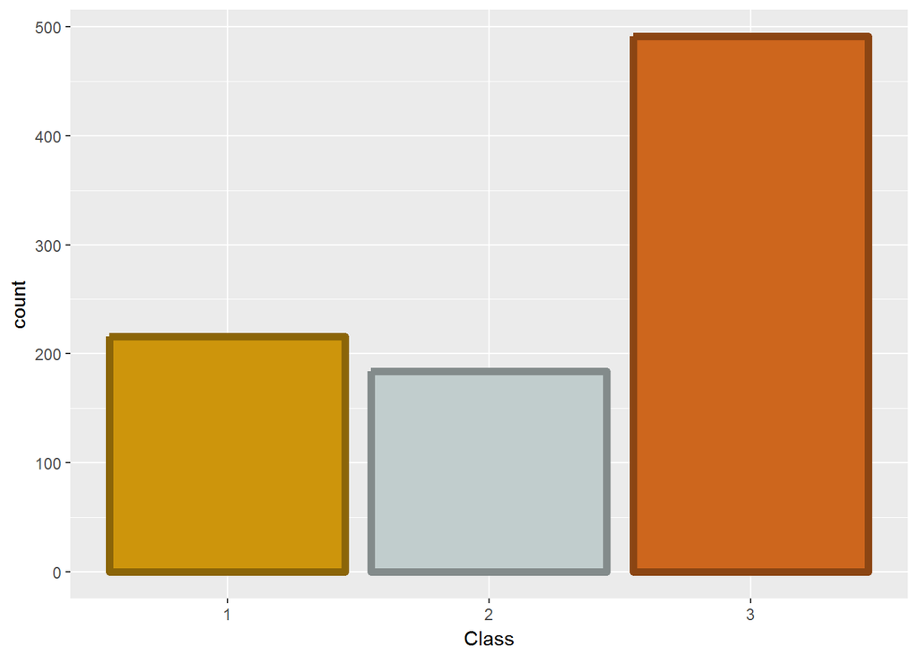

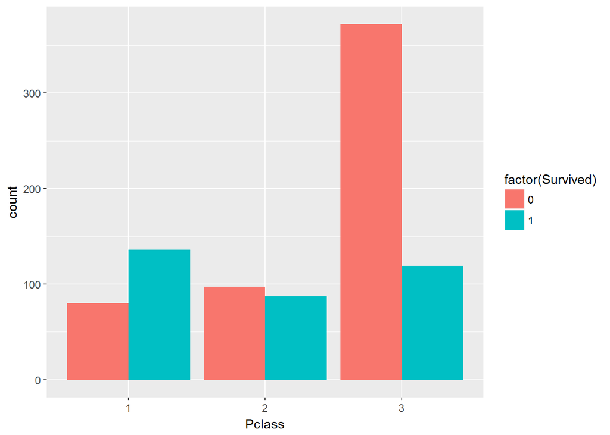

### 3.3.2 Name

La longitud promedio de un nombre es de 27 caracteres con un máximo de 82.

```r
# Resumen de las longitudes del nombre
summary(sapply(as.character(unique(titanic_train$Name)),nchar))
```

```
##    Min. 1st Qu.  Median    Mean 3rd Qu.    Max.
##   12,00   20,00   25,00   26,97   30,00   82,00
```

### 3.3.3 Sex

Casi el doble de hombres:

```r
#Casi el doble de hombres
summary(titanic_train$Sex)
```

```
## female   male
##    314    577
```

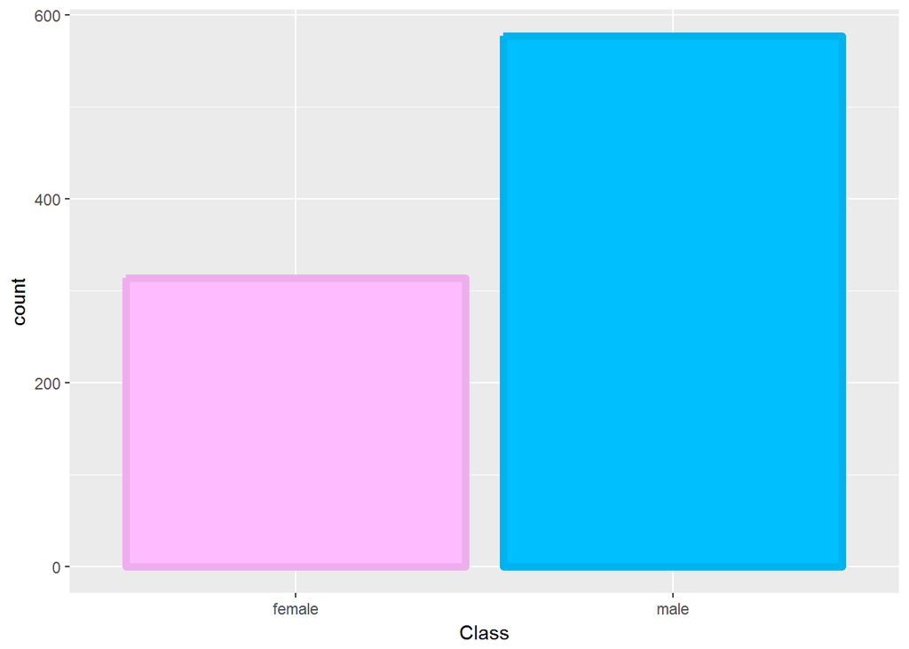

```r
sb <- ggplot(titanic_train, aes(x=Sex)) +
  geom_bar(fill=c(colors()[542], colors()[121]),
           col=c(colors()[543], colors()[123]), lwd = 2) +
  labs(x="Class")
sb
```

### 3.3.4 Age

Promedio de edad alrededor de los 30 años con 177 NA. Existe una necesidad de encontrar una forma de imputar estos valores.

```r
# # 177 NA's, la edad media es 28 años aka nacido en 1884 (inicio de la entrada)
summary(titanic_train$Age)
```

```
##    Min. 1st Qu.  Median    Mean 3rd Qu.    Max.    NA's
##    0,42   20,12   28,00   29,70   38,00   80,00     177
```

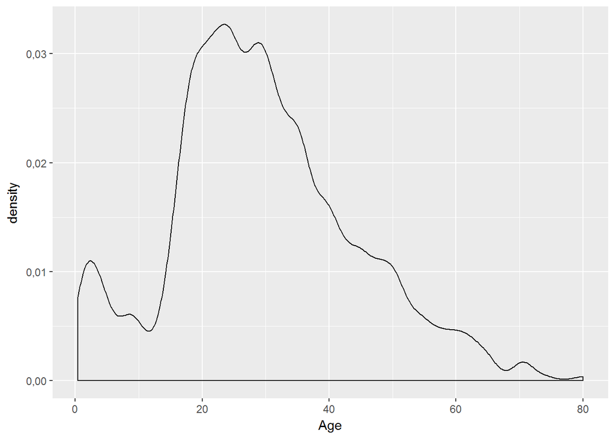

```r
ap <- ggplot(titanic_train, aes(x=Age))+geom_density(adjust=.5)
ap
```

### 3.3.5 Hermanos y cónyuges

```r
unique(titanic_train$SibSp)
```

```
## [1] 1 0 3 4 2 5 8
```

```r
# Max Spouse es 1, crea datos de hermanos
# Max parents is 2, create children data
# Recopilar datos de riqueza de los puntos de embarque
titanic_train$SibSp <- as.integer(titanic_train$SibSp) #posiblemente solo frente a variable familiar
summary(titanic_train$SibSp) #mediana es 0
```

```
##    Min. 1st Qu.  Median    Mean 3rd Qu.    Max.
##   0,000   0,000   0,000   0,523   1,000   8,000
```

```r
dim(titanic_train[titanic_train$SibSp > 0,])
```

```
## [1] 283  11
```

```r
dim(titanic_train[titanic_train$SibSp == 0,])
```

```
## [1] 608  11
```

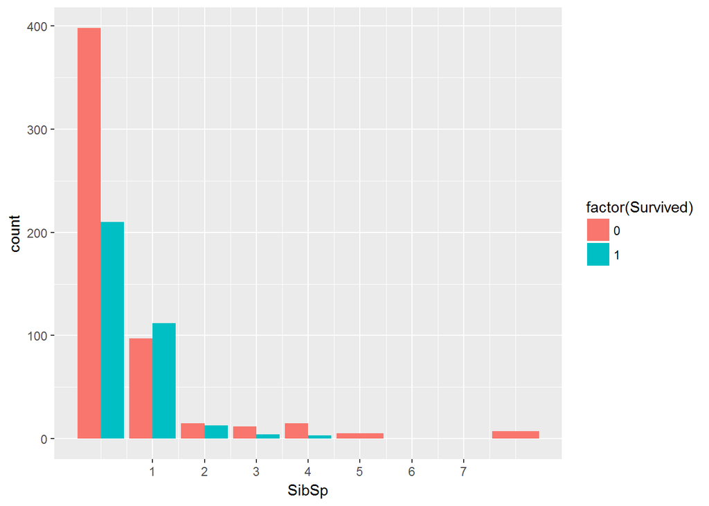

```r
ggplot(titanic_train, aes(x = SibSp, fill = factor(Survived))) +
  geom_bar(stat='count', position='dodge') +
  scale_x_continuous(breaks=c(1:7)) +
  labs(x = 'SibSp')
```

Estas tablas sugieren que la única configuración beneficiosa es tener 1 hermano o cónyuge. Ellos son el único grupo que tiene más probabilidades de sobrevivir. Esto podría ser indicativo de madres solteras, o tal vez de parejas, aunque Jack y Rose son un contador formidable de esa proposición.

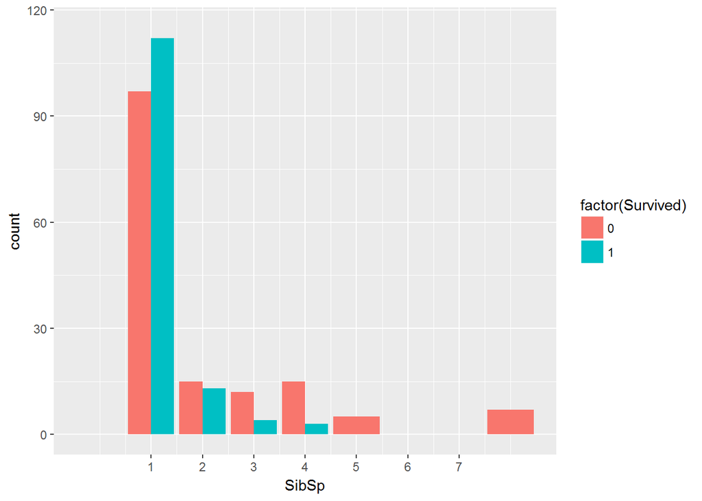

### 3.3.6 Padres e hijos

Esto también sugiere que la mayoría de la gente no tiene familia. Aproximadamente 1/4 tienen padres o niños a bordo.

```r
unique(titanic_train$Parch)
```

```
## [1] 0 1 2 5 3 4 6
```

```r
summary(titanic_train$Parch)
```

```
##    Min. 1st Qu.  Median    Mean 3rd Qu.    Max.
##  0,0000  0,0000  0,0000  0,3816  0,0000  6,0000
```

Hay 213 personas que viajan con sus hijos o padres.

```r
dim(titanic_train[titanic_train$Parch > 0,])
```

```
## [1] 213  11
```

Los otros 678 están solos.

```r
dim(titanic_train[titanic_train$Parch == 0,])
```

```
## [1] 678  11
```

Este primer cuadro muestra la abrumadora desventaja de viajar solo.

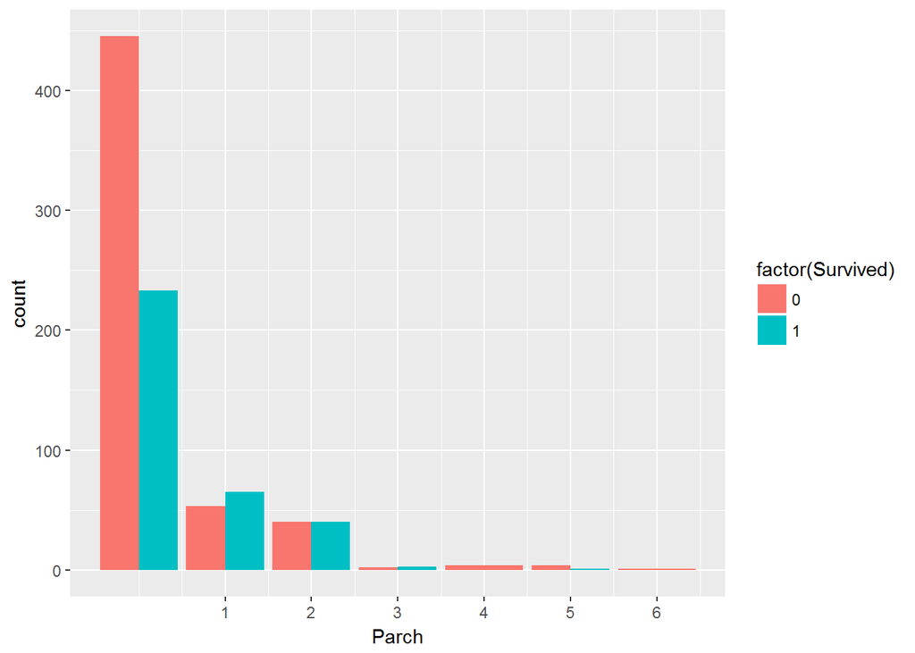

Este muestra que tener una relación 1-3 niños/padres es potencialmente beneficioso.

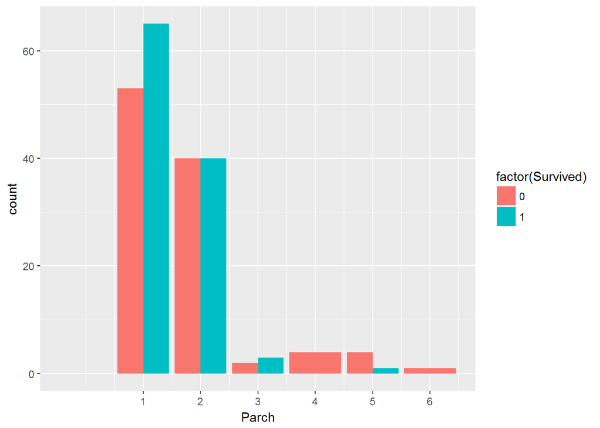

### 3.3.7 Ticket

Hay 681 identificadores de tickets únicos. Los boletos tienen identificadores de prefijo y dígitos iniciales limitados que podrían codificar más información sobre el pasajero.

```
## [1] 681
```

Este gráfico muestra que algunos de los prefijos de tickt están asociados con precios más altos. La tarifa ya debería dar cuenta de esta variación, por lo tanto, a menos que podamos encontrar otra relación con el prefijo, entonces no vale la pena incluir esta variable.

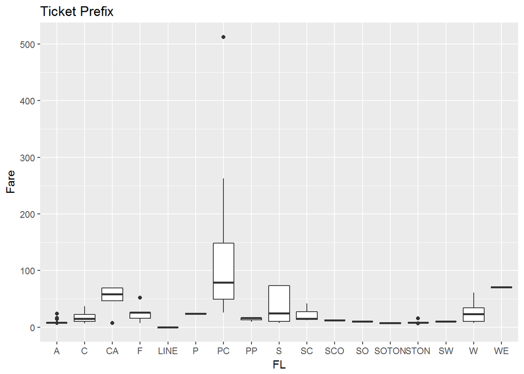

Esto confirma que el ticket codifica más información, pero para que sea útil tendrá que cavar más profundo. La gráfica a continuación muestra que aquellos con el prefijo de ticket para PC tienen muchas más probabilidades de sobrevivir. Este gráfico está confundido por el precio del boleto. Algunos de los prefijos son intrigantes. A, CA, SOTON y W tienen tasas de bajas extremadamente altas en relación con todas las demás.

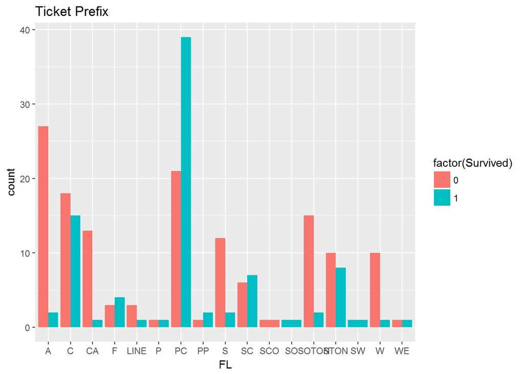

Si profundizamos un poco más, ¿qué tienen en común estos prefijos? Si miramos la longitud de los componentes numéricos de los tickets, encontramos algo interesante: Los sufijos que mencionamos generalmente tienen números de ticket más cortos. El máximo es 2 menos, y la mediana es 2 menos. Esto es particularmente interesante porque hay entradas sin prefijos que también tienen entradas más cortas, así que tal vez tengamos algo bueno.

```r
tfix <- tpref[tpref$FL %in% c("A", "CA", "Soton", "W"),]
summary(sapply(as.character(titanic_train$FT),nchar))
```

```
##    Min. 1st Qu.  Median    Mean 3rd Qu.    Max.    NA's
##   3,000   5,000   6,000   5,375   6,000   7,000       6
```

```r
summary(sapply(as.character(tfix$FT), nchar))
```

```
##    Min. 1st Qu.  Median    Mean 3rd Qu.    Max.
##   3,000   4,000   4,000   4,315   5,000   5,000
```

Regresaremos sobre esto más tarde una vez que completemos esta decodificación.

```r
titanic_train$ticketlength <- sapply(as.character(titanic_train$FT),nchar)
```

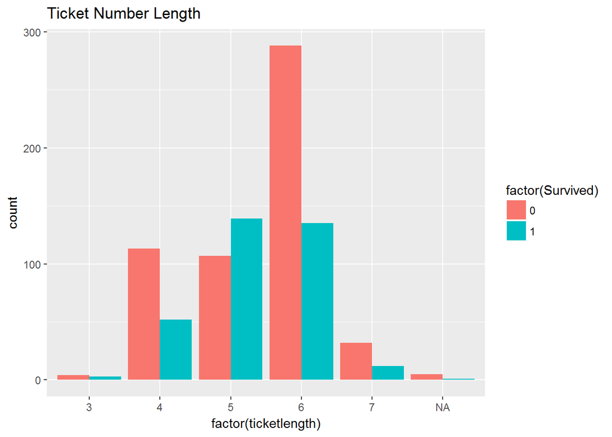

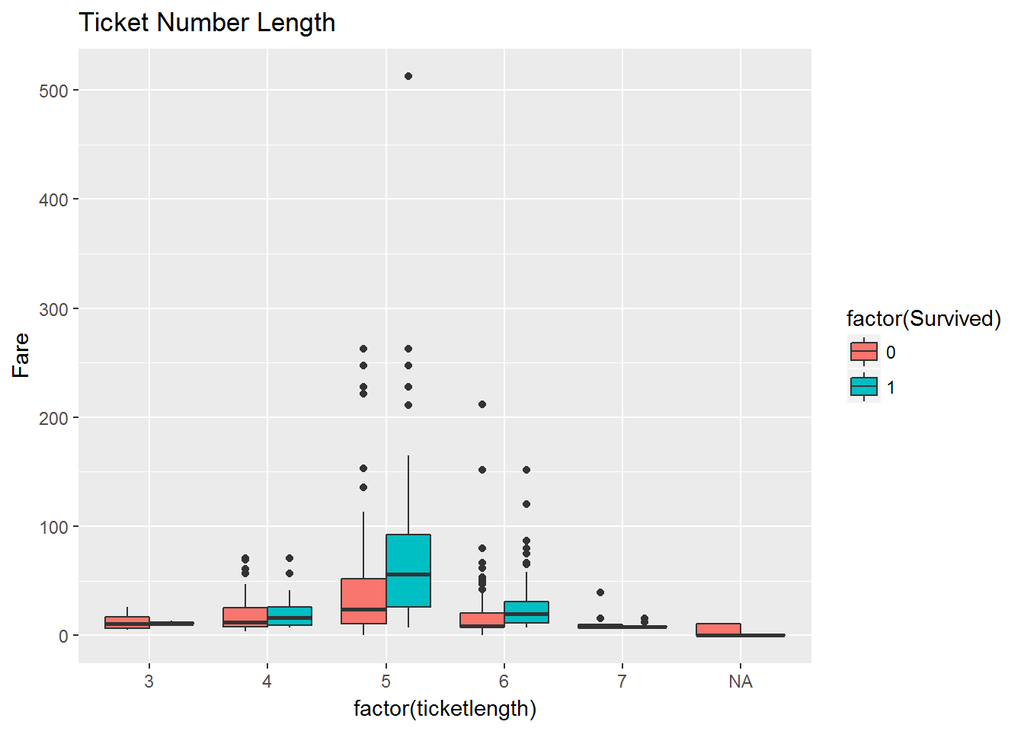

A riesgo de ir un paso demasiado lejos, veamos los números de los boletos individuales. La premisa es que no son aleatorios y potencialmente codifican datos de ubicación de pasajeros que podrían afectar el resultado de la supervivencia. El desglose de los precios se incluye junto para verificar el efecto de confusión.

Desde mi punto de vista, parece que hay efectos interesantes sucediendo en los primeros 5 dígitos. La gran noticia es que no tenemos que entenderlo completamente: ahí es donde entra el aprendizaje automático.

[figure not shown]

### 3.3.8 Fare

```r
titanic_train[titanic_train$Fare==0,]$Sex
```

```
##  [1] male male male male male male male male male male male male male male
## [15] male
## Levels: female male
```

Hay 248 precios únicos de entradas.

```r
length(unique(titanic_train$Fare))
```

```
## [1] 248
```

Como se esperaba, la primera clase es mucho más costosa.

```r
titanic_train %>% group_by(Pclass) %>% summarise_each(funs(min, max, mean, median),Fare)
```

```
## # A tibble: 3 x 5
##   Pclass Fare_min Fare_max Fare_mean Fare_median
##   <fctr>    <dbl>    <dbl>     <dbl>       <dbl>
## 1 1             0    512        84.2       60.3
## 2 2             0     73.5      20.7       14.2
## 3 3             0     69.6      13.7        8.05
```

```r
titanic_train %>% group_by(Sex) %>% summarise_each(funs(min, max, mean, median),Fare)
```

```
## # A tibble: 2 x 5
##   Sex    Fare_min Fare_max Fare_mean Fare_median
##   <fctr>    <dbl>    <dbl>     <dbl>       <dbl>
## 1 female     6.75      512      44.5        23.0
## 2 male       0         512      25.5        10.5
```

### 3.3.9 Cabin

```r
length(unique(titanic_train$Cabin))
```

```
## [1] 148
```

```
## [1] 204
```

| Cabin | Count |
| --- | --- |
|  | 687 |
| B96 B98 | 4 |
| C23 C25 C27 | 4 |
| G6 | 4 |
| C22 C26 | 3 |
| D | 3 |
| E101 | 3 |
| F2 | 3 |
| F33 | 3 |
| B18 | 2 |

[output cut: 90 more lines]

Creamos ahora una variable de la letra de Cabin.

```r
titanic_train$CL <- substring(titanic_train$Cabin, 1, 1)
titanic_train$CL <- as.factor(titanic_train$CL)
unique(titanic_train$CL)
```

```
## [1]   C E G D A B F T
## Levels:  A B C D E F G T
```

El subconjunto es desproporcionado para la primera clase en Cherbourg y Southampton.

```r
summary(titanic_train[!substring(titanic_train$Cabin, 1, 1) == "",]$Embarked)
```

```
##       C   Q   S
##   2  69   4 129
```

```r
summary(titanic_train[!substring(titanic_train$Cabin, 1, 1) == "",]$Pclass)
```

```
##   1   2   3
## 176  16  12
```

El primer gráfico muestra que las cabinas B y C son más caras.

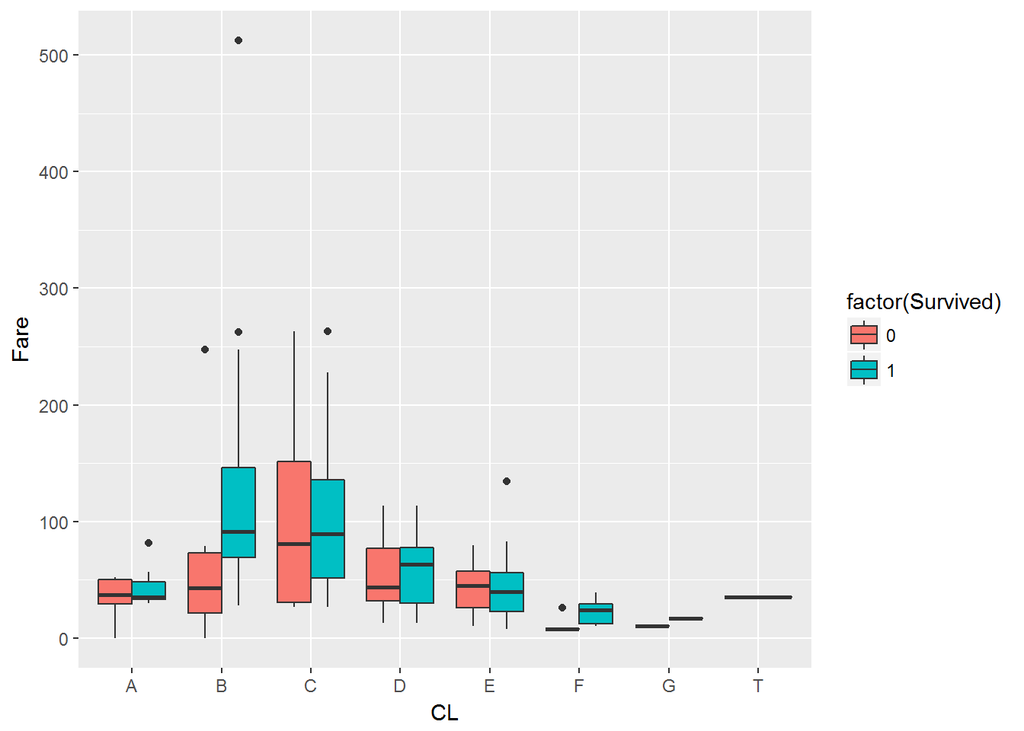

El segundo gráfico muestra que puede haber algunas relaciones interesantes aquí para la supervivencia. Es importante recordar que este subconjunto ya es más probable que sobreviva debido a su estado de primera clase.

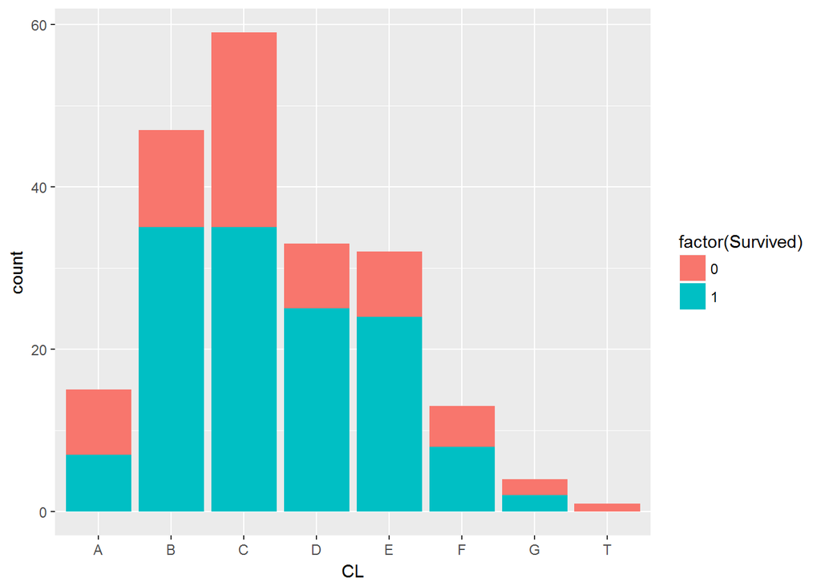

Según los datos, parece difícil imputar con precisión las asignaciones de cabina para el resto del conjunto de datos. En cambio, creemos un variable binaria para “habitación asignada” o “no asignada”. Esto podría representar una mayor variación en el conjunto de datos inicial. Una de las hipótesis es que las personas que tienen asignada una habitación tienen alguna posición o estatus y tienen prioridad de elección, lo que puede reflejarse en relación con su supervivencia.

```r
titanic_train$Assigned <- 0
titanic_train[!substring(titanic_train$Cabin, 1, 1) == "",]$Assigned <- 1
```

### 3.3.10 Embarked

Hay 3 ubicaciones de salida, la mayoría de las personas son de Southampton, Cherburgo y Queenstown.

```r
unique(titanic_train$Embarked)
```

```
## [1] S C Q
## Levels:  C Q S
```

```r
summary(titanic_train$Embarked)
```

```
##       C   Q   S
##   2 168  77 644
```

Hay 2 valores faltantes para el punto de embarque. Lo que nos lleva a la imputación.

|  | Survived | Pclass | Name | Sex | Age | SibSp | Parch | Ticket | Fare | Cabin | Embarked | FL | FT | ticketlength | one | two | three | four | five | six | seven | CL | Assigned |
| --- | --- | --- | --- | --- | --- | --- | --- | --- | --- | --- | --- | --- | --- | --- | --- | --- | --- | --- | --- | --- | --- | --- | --- |
| 1 | 1 | 1 | Icard, Miss. Amelie | female | 38 | 0 | 0 | 113572 | 80 | B28 |  | NA | 113572 | 6 | 1 | 1 | 3 | 5 | 7 | 2 |  | B | 1 |
| 2 | 1 | 1 | Stone, Mrs. George Nelson (Martha Evelyn) | female | 62 | 0 | 0 | 113572 | 80 | B28 |  | NA | 113572 | 6 | 1 | 1 | 3 | 5 | 7 | 2 |  | B | 1 |

### 3.3.11 Ajuste de los datos con ceros o valores nulos

```
##     Survived       Pclass         Name          Sex          Age
##            0            0            0            0           NA
##        SibSp        Parch       Ticket         Fare        Cabin
##            0            0            0            0          687
##     Embarked           FL           FT ticketlength          one
##            2            0           NA           NA           NA
##          two        three         four         five          six
##           NA           NA           NA           NA           NA
##        seven           CL     Assigned
##           NA          687            0
```

```
##     Survived       Pclass         Name          Sex          Age
##            0            0            0            0          177
##        SibSp        Parch       Ticket         Fare        Cabin
##            0            0            0            0            0
##     Embarked           FL           FT ticketlength          one
##            0            0            6            6            6
##          two        three         four         five          six
##            6            6            6            6            6
##        seven           CL     Assigned
##            6            0            0
```

Ajustamos los datos faltantes en la variable Age:

```r
titanic_train <- as.data.frame(titanic_train)
#imputar los valores de edad faltantes con el paquete MICE
impute <- mice(titanic_train[, !names(titanic_train) %in% c('PassengerId','Name','Ticket','Cabin','Survived', 'Assigned','FL','FT','ticketlength','one','two','three','four','five','six','seven')], method='rf')

trained_mouse <- complete(impute)
```

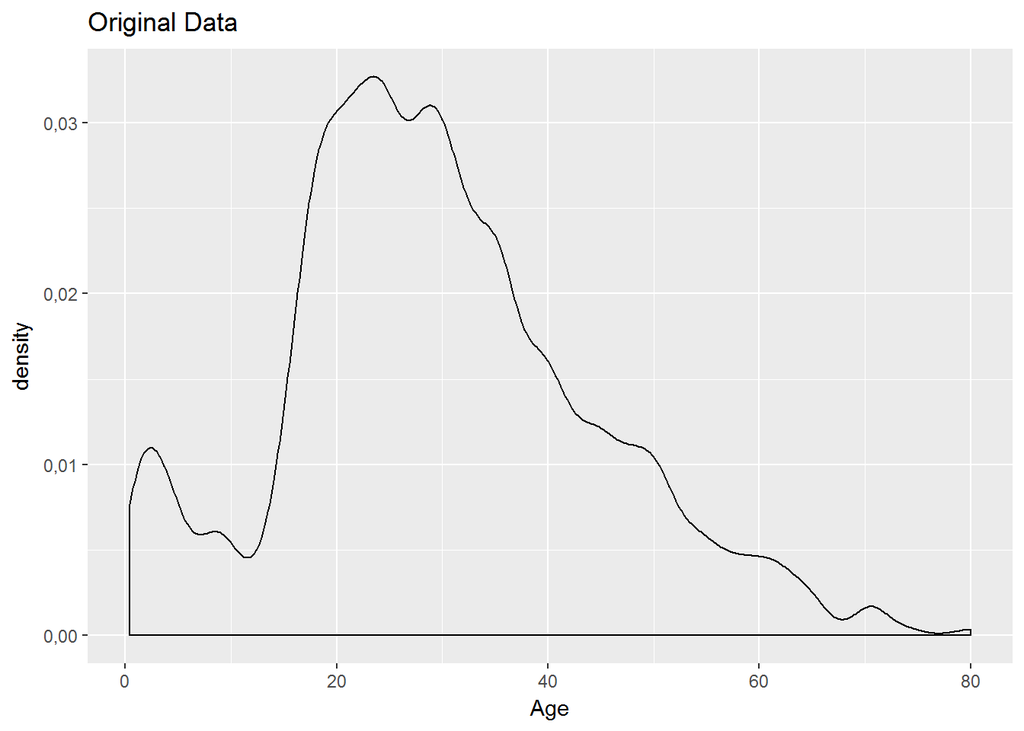

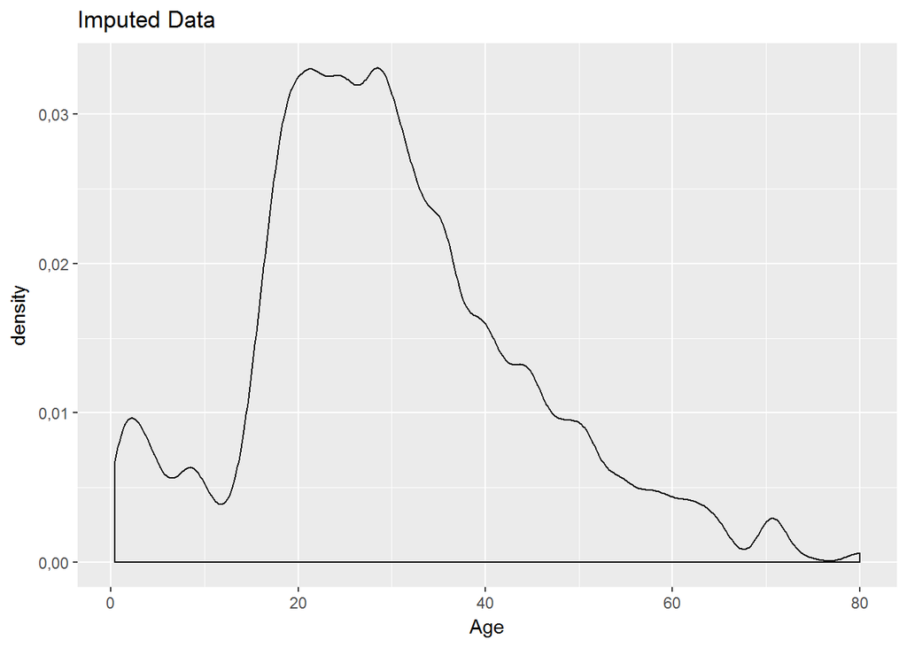

Dado que los resultados están razonablemente bien emparejados, podemos reemplazar la columna original con los valores imputados.

```r
titanic_train$Age <- trained_mouse$Age
```

**Ahora vamos a analizar y ajustar los valores en la variable Enbarked.**

Ahora estamos en esos 2 valores de la variable Embarked que faltan. Lo primero que viene a la mente es verificar con el valor de la variable Cabin. A partir de los datos, todas las cabinas que comienzan en B se embarcaron desde Southampton o Charbourg.

```r
unique(titanic_train[grep("*^B", titanic_train$Cabin),]$Embarked)
```

```
## [1] C   S
## Levels:  C Q S
```

Los billetes de viaje cuestan 80 USD, que es muy similar a la tarifa promedio de los pasajeros S en cabinas tipo B.

```
## # A tibble: 3 x 2
##   Embarked  Fare
##   <fctr>   <dbl>
## 1 ""        80.0
## 2 C        146
## 3 S         85.4
```

Sin embargo, la tarifa es más cercana a la mediana de la variable Fare de pasajeros tipo C.

```
## # A tibble: 3 x 2
##   Embarked  Fare
##   <fctr>   <dbl>
## 1 ""        80.0
## 2 C         79.2
## 3 S         86.5
```

Entonces, lo que parece ser un inocente valor perdido aislado es en realidad una pregunta interesante sobre la imputación basada en la media o la mediana.

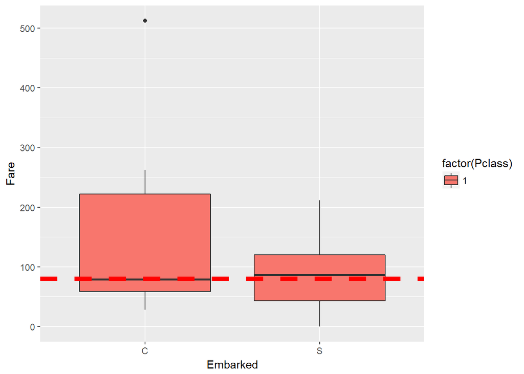

Puede parecer razonable imputar por la mediana de las tarifas de C porque ese es el valor más cercano. Sin embargo, si miramos hacia atrás en la sección de tarifas, vemos que hay un 72,4% de posibilidades de que un pasajero determinado se embarque desde S.

```
##       C   Q   S
##   2 168  77 644
```

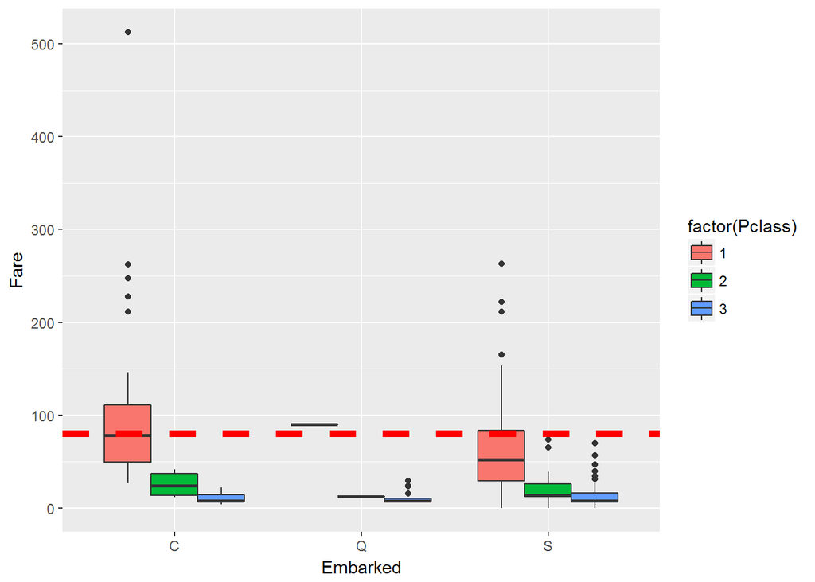

```
##     C  Q  S
##  2 22  0 23
```

Al final, decidí ampliar ‘S’ a la variable y ver dónde eso nos conduce en el análisis posterior.

```r
titanic_train$Embarked[c(62, 830)] <- 'S'
```

# 4 Análisis de las variables del dataset titanic

Para los fines de este estudio, trabajamos con solo cuatro variables de entrada y una variable de respuesta. Como se mencionó anteriormente, las cuatro variables de entrada son Class, Sex, Age y Puerto de Embarque. La variable de respuesta es si sobrevivieron o no.

Podemos recortar los datos según nuestras necesidades usando los siguientes comandos:

```r
df = titanic_train[,c(1,2,4,5,11)]
```

También hacemos que Age sea una variable categórica de la siguiente manera:

- Si age <= 18, entonces age = child
- Si 18 < age <= 60, entonces age = adult
- Si age > 60, entonces age = senior

```r
df$Age[df$Age <= 18] = "child"
df$Age[(df$Age > 18) & (df$Age <= 60) & (df$Age != "child")] = "adult"
df$Age[(df$Age != "child") & (df$Age != "adult")] = "senior"
df$Age = as.factor(df$Age)
```

Después de realizar esta operación, nuestros datos se ven así:

Dataset seleccionado

| Survived | Pclass | Sex | Age | Embarked |
| --- | --- | --- | --- | --- |
| 0 | 3 | male | adult | S |
| 1 | 1 | female | adult | C |
| 1 | 3 | female | adult | S |
| 1 | 1 | female | adult | S |
| 0 | 3 | male | adult | S |
| 0 | 3 | male | adult | Q |

|  | Survived | Pclass | Sex | Age | Embarked |
| --- | --- | --- | --- | --- | --- |
| 1 | 0 | 3 | male | adult | S |
| 2 | 1 | 1 | female | adult | C |
| 3 | 1 | 3 | female | adult | S |
| 4 | 1 | 1 | female | adult | S |
| 5 | 0 | 3 | male | adult | S |
| 6 | 0 | 3 | male | adult | Q |
| 7 | 0 | 1 | male | adult | S |
| 8 | 0 | 3 | male | child | S |
| 9 | 1 | 3 | female | adult | S |
| 10 | 1 | 2 | female | child | C |

[output cut: 881 more lines]

```r
summary(df)
```

```
##  Survived Pclass      Sex          Age      Embarked
##  0:549    1:216   female:314   adult :698    :  0
##  1:342    2:184   male  :577   child :161   C:168
##           3:491                senior: 32   Q: 77
##                                             S:646
```

## 4.1 Diseño experimental

El análisis de datos está organizado de la siguiente manera:

### 4.1.1 Justificación del diseño

La justificación racional detrás de este diseño es la siguiente. Claramente, tenemos un conjunto de datos a mano que se compone de cuatro variables de entrada, tres de las cuales son categóricas y la cuarta es numérica discreta. La variable de respuesta también es categórica.

Lo primero que se me ocurre es analizar individualmente el efecto de cada una de las variables de entrada en la variable de respuesta. Esto no es más que calcular los efectos principales.

El segundo nivel de investigación que se me ocurre es comprobar si un par de dos factores tiene un efecto sinérgico en la variable de respuesta que parece ser más que el efecto combinado de los dos factores. Esto no es más que computar los efectos de interacción.

En tercer lugar, desde un punto de vista puramente estadístico, estamos tratando con muestras de cuatro variables aleatorias como entradas. Si solo tuviéramos muestras de dos variables aleatorias, habríamos optado por una prueba z o una prueba t. Sin embargo, dado que hay más de dos variables aleatorias, se prefiere ANOVA, ya que hace exactamente eso.

Las siguientes subsecciones arrojan luz sobre los temas de aleatorización, Replicación y Medidas repetidas, y Bloqueo desde un punto de vista puramente teórico, así como desde el punto de vista de este estudio.

### 4.1.2 Aleatorización

La aleatorización se realiza para permitir la mayor fiabilidad y validez de las estimaciones estadísticas de los efectos del tratamiento. Más precisamente, se refiere a asignar aleatoriamente las unidades experimentales a través de los grupos de tratamiento. La aleatorización reduce el sesgo al minimizar el efecto de los factores de molestia o el ruido estocástico en los datos.

En este estudio, los pasajeros del Titanic se dividieron en tres clases separadas, determinadas por su precio de boleto y su riqueza y clase social. Los pasajeros en primera clase eran los más ricos del lote e incluían personas prominentes de clase alta, hombres de negocios, políticos, personal militar de alto rango, industriales, banqueros, etc. Los pasajeros de segunda clase incluían profesores, autores, clérigos, turistas, etc. Pasajeros en tercera clase fueron emigrantes que se mudaron a los Estados Unidos y Canadá. Además, los pasajeros fueron variados en etnia también. Hubo pasajeros del Imperio Otomano, otros tenían orígenes árabes, etc. Por lo tanto, para los fines de este estudio, hubo una buena cantidad de aleatorización de los pasajeros en función de su nacionalidad, etnia, condición económica, condición social, riqueza, etc.

### 4.1.3 Replicación y / o medidas repetidas

La replicación se refiere a la repetición de un experimento para reducir la variabilidad asociada con el fenómeno que se estudia. En cualquier proceso de muestreo, la variación que es inherente no se puede eliminar, pero lo mejor que se puede hacer es eliminar la variación causada por causas especiales. Esto es lo que se logra mediante la Replicación.

Hay una línea delgada que separa la replicación de medidas repetidas. La medición repetida se refiere al uso de los mismos sujetos dentro de cada rama del estudio, incluido el grupo de control.

En este estudio, los datos disponibles están escritos en piedra. Realizar la replicación significaría hacer que el barco del Titanic navegue varias veces y recopilar los datos en todos esos viajes: algunos de los cuales pueden hundirse y otros no. Realizar medidas repetidas significaría hacer que la nave del Titanic navegue en un número de universos paralelos con el mismo grupo de pasajeros. Claramente, ambos no son prácticos y, por lo tanto, en nuestro estudio, no hay evidencia de replicación o medidas repetidas.

### 4.1.4 Bloqueo

El bloqueo se refiere a organizar unidades experimentales en grupos (bloques) que son similares entre sí de alguna manera, forma o forma. Estos bloques se analizan juntos para reducir la variabilidad conocida. La idea principal detrás del bloqueo es que una variabilidad que ocurre en cualquiera de las variables de entrada que no se pueden superar se confunde con una interacción para eliminar su influencia en la variable de respuesta.

La base teórica para el bloqueo se puede entender a partir de la siguiente ecuación. Dadas dos variables aleatorias X e Y,

Var (X-Y) = Var (X) + Var (Y) -2Cov (X, Y)

La varianza de la diferencia se puede minimizar maximizando la covarianza (o la correlación) entre X e Y.

En este estudio, hemos analizado los datos como un todo porque no había ninguna razón para sospechar la existencia de variabilidad conocida para ninguna de las variables de entrada consideradas.

## 4.2 Análisis estadístico

### 4.2.1 Análisis exploratorio de datos

Resumen de los datos limpios:

```r
summary(df)
```

```
##  Survived Pclass      Sex          Age      Embarked
##  0:549    1:216   female:314   adult :698    :  0
##  1:342    2:184   male  :577   child :161   C:168
##           3:491                senior: 32   Q: 77
##                                             S:646
```

Visualizamos los histogramas de las cuatro variables de entrada:

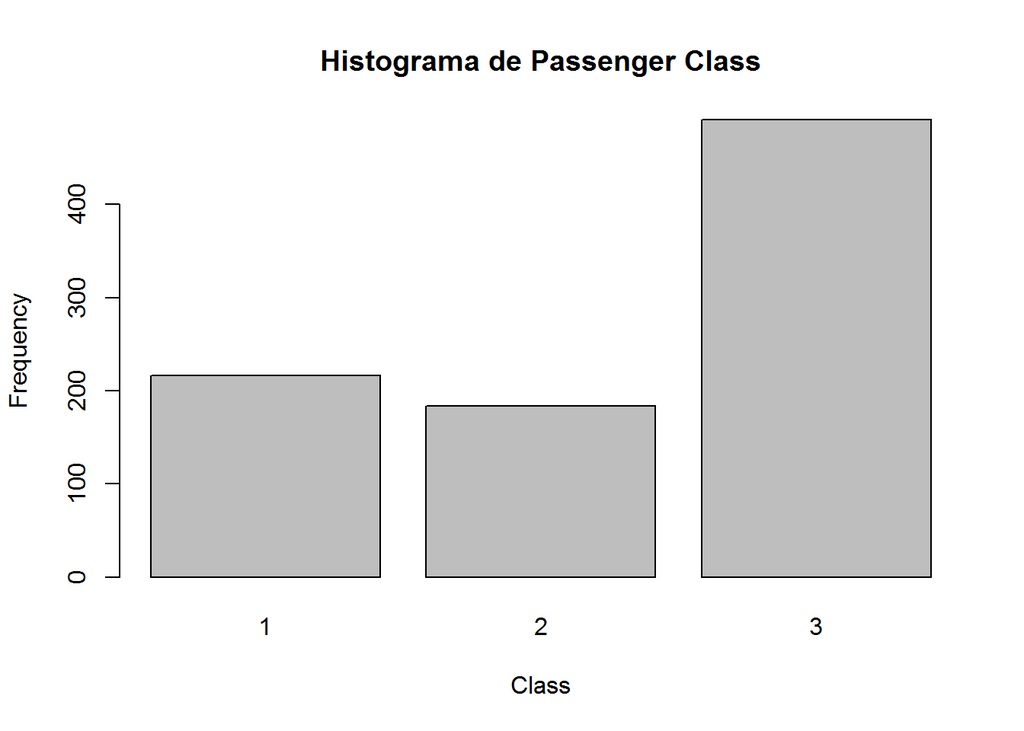

```r
barplot(table(df$Pclass), xlab="Class", ylab="Frequency", main="Histograma de Passenger Class")
```

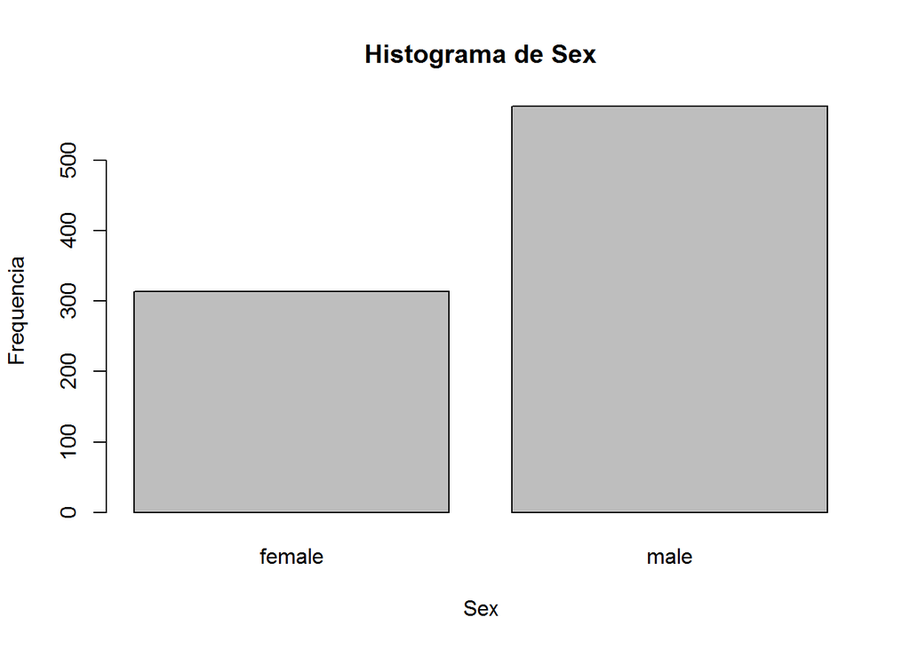

```r
barplot(table(df$Sex), xlab="Sex", ylab="Frequencia", main="Histograma de Sex")
```

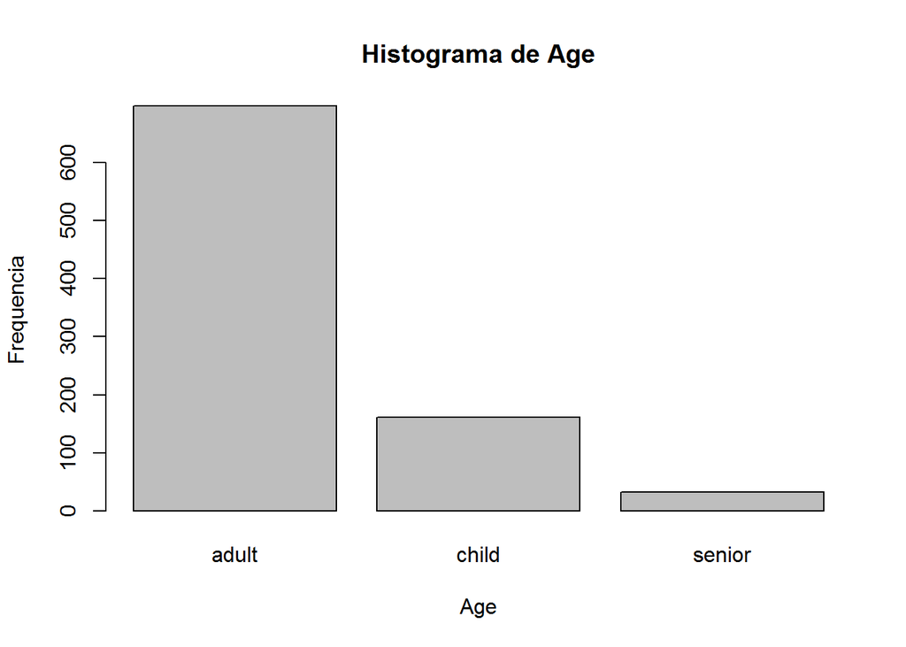

```r
barplot(table(df$Age), xlab="Age", ylab="Frequencia", main="Histograma de Age")
```

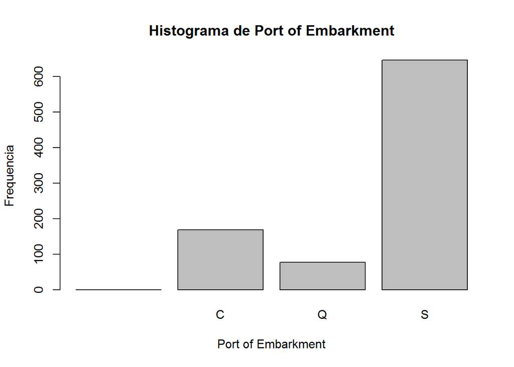

```r
barplot(table(df$Embarked), xlab="Port of Embarkment", ylab="Frequencia", main="Histograma de Port of Embarkment")
```

### 4.2.2 Test

Antes de comenzar con las pruebas, convertimos el dataframe categórico en un dataframe numérico.

```r
old_df = df
df$Pclass = as.integer(df$Pclass)
df$Sex = as.integer(df$Sex)
df$Age = as.integer(df$Age)
df$Embarked = as.integer(df$Embarked)
df$Survived = as.integer(df$Survived)
head(df)
```

```
##   Survived Pclass Sex Age Embarked
## 1        1      3   2   1        4
## 2        2      1   1   1        2
## 3        2      3   1   1        4
## 4        2      1   1   1        4
## 5        1      3   2   1        4
## 6        1      3   2   1        3
```

Parece haber más sobrevivientes en promedio de la 1ra clase en comparación con los otros dos. El número más bajo de sobrevivientes en promedio fue de la 3ra clase.

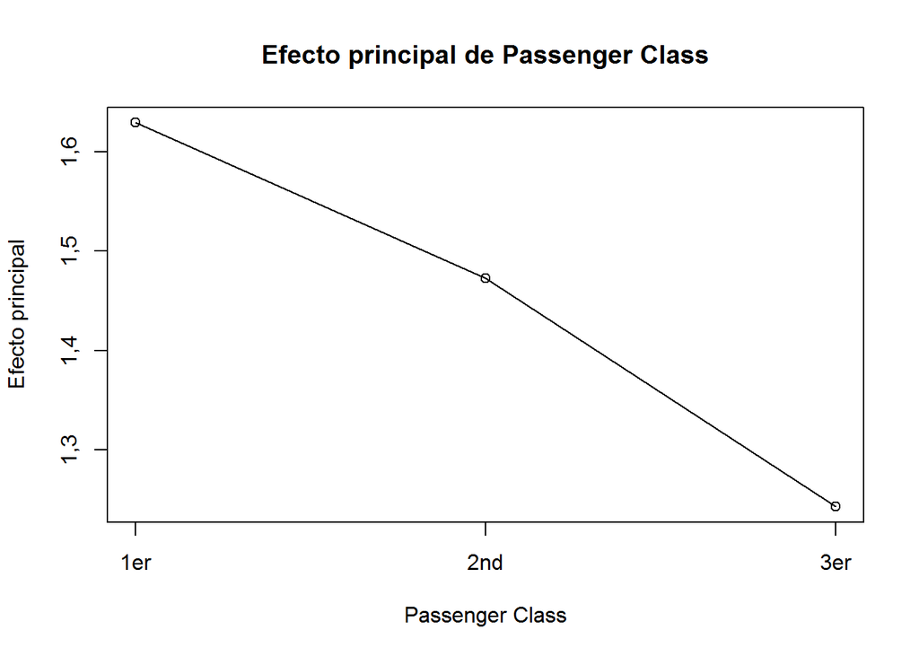

```r
me_pclass = c(0,0,0)
me_pclass[1] = mean(df$Survived[df$Pclass==1])
me_pclass[2] = mean(df$Survived[df$Pclass==2])
me_pclass[3] = mean(df$Survived[df$Pclass==3])
plot(me_pclass, type="o", main="Efecto principal de Passenger Class", xlab="Passenger Class", ylab="Efecto principal",
     xaxt="n")
axis(1, at=c(1,2,3), labels=c("1er", "2nd", "3er"))
```

Las sobrevivientes femeninas eran mucho más numerosas que los hombres.

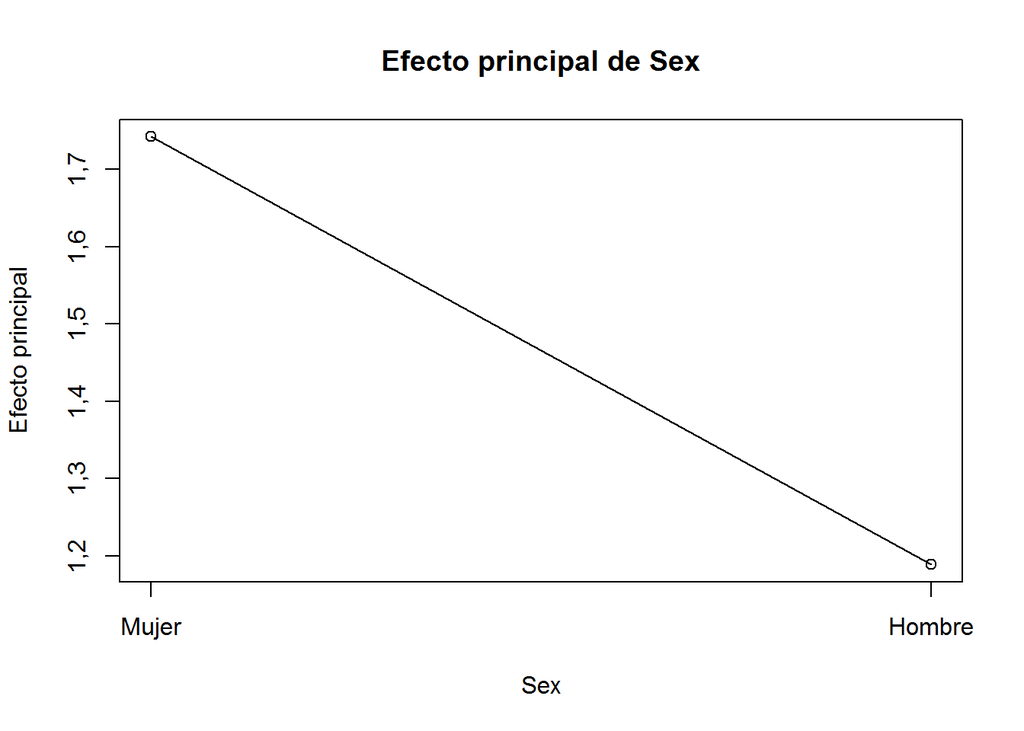

```r
me_sex = c(0,0)
me_sex[1] = mean(df$Survived[df$Sex==1])
me_sex[2] = mean(df$Survived[df$Sex==2])
plot(me_sex, type="o", main="Efecto principal de Sex", xlab="Sex", ylab="Efecto principal", xaxt="n")
axis(1, at=c(1,2), labels=c("Mujer", "Hombre"))
```

Los supervivientes máximos en promedio de la categoría de edad eran niños, seguidos de adultos y personas mayores.

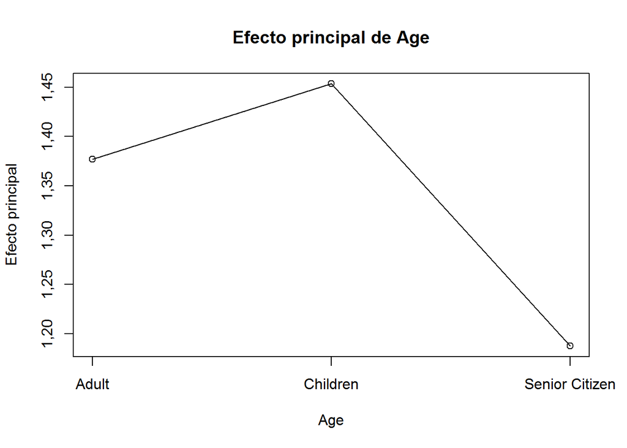

```r
me_age = c(0,0,0)
me_age[1] = mean(df$Survived[df$Age==1])
me_age[2] = mean(df$Survived[df$Age==2])
me_age[3] = mean(df$Survived[df$Age==3])
plot(me_age, type="o", main="Efecto principal de Age", xlab="Age", ylab="Efecto principal", xaxt="n")
axis(1, at=c(1,2,3), labels=c("Adult", "Children", "Senior Citizen"))
```

[figure not shown]

```r
me_emb = c(0,0,0)
me_emb[1] = mean(df$Survived[df$Embarked==1])
me_emb[2] = mean(df$Survived[df$Embarked==2])
me_emb[3] = mean(df$Survived[df$Embarked==3])
plot(me_emb, type="o", main="Efecto principal de Port of Embarkment", xlab="Port of Embarkment", ylab="Efecto principal",
     xaxt="n")
axis(1, at=c(1,2,3), labels=c("Cherbourg", "Queenstown", "Southampton"))
```

Existe un claro efecto de interacción entre la clase de pasajeros y el sexo. Los pasajeros femeninos de primera y segunda clase tuvieron un mayor número de sobrevivientes que las pasajeras de tercera clase. Los pasajeros varones de primera clase tenían un número promedio mayor de sobrevivientes que los pasajeros masculinos de segunda y tercera clase.

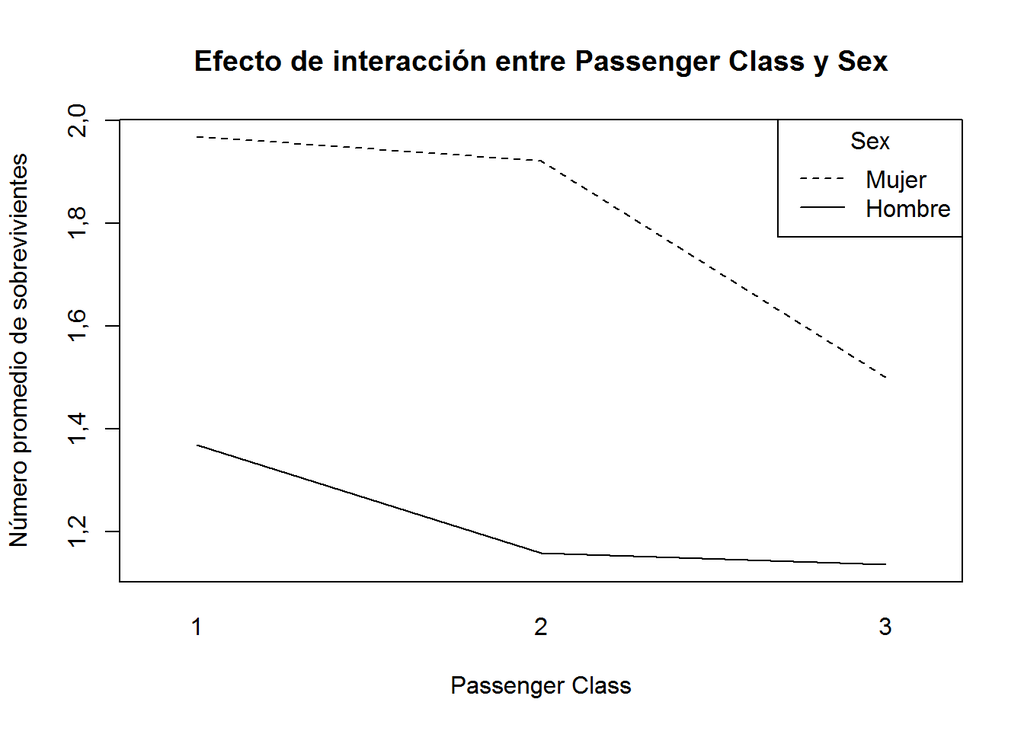

```r
interaction.plot(df$Pclass, df$Sex, df$Survived, xlab="Passenger Class", ylab="Número promedio de sobrevivientes",
                  main="Efecto de interacción entre Passenger Class y Sex", legend=FALSE)
legend("topright", c("Mujer","Hombre"), lty=c("dashed", "solid"), title="Sex")
```

[figure not shown]

```r
interaction.plot(df$Pclass, df$Age, df$Survived, xlab="Passenger Class", ylab="Número promedio de sobrevivientes",
                 main="Efecto de interacción entre Passenger Class y Age", legend=FALSE)
legend("topright", c("Adult","Child", "Senior"), lty=c("dashed", "solid", "dotted"), title="Age")
```

[figure not shown]

```r
interaction.plot(df$Pclass, df$Embarked, df$Survived, xlab="Passenger Class", ylab="Número promedio de sobrevivientes",
                 main="Efecto de interacción entre Passenger Class y Port of Embarkment", legend=FALSE)
legend("topright", c("Cherbourg","Queenstown","Southampton"), lty=c("dashed", "solid", "dotted"),
       title="Port of Embarkment")
```